# Question

Here are some common (and less common) parent functions:

| name | $f(x)=$ |
| --- | --- |
| constant | 1 |
| linear | $x$ |
| absolute | $\|x\|$ |
| quadratic | $x^2$ |
| cubic | $x^3$ |
| reciprocal | $\frac{1}{x}$ |
| square root | $\sqrt{x}$ |
| cube root | $\sqrt[3]{x}$ |
| sine | $\sin(x)$ |
| cosine | $\cos(x)$ |
| tangent | $\tan(x)$ |
| ceiling | $\lceil x \rceil$ |
| floor | $\lfloor x \rfloor$ |
| exponential | $e^x$ |
| logarithmic | $\ln(x)$ |
| logistic | $\frac{e^x}{e^x+1}$ |
| squared reciprocal | $\frac{1}{x^2}$ |

Use [Desmos](https://www.desmos.com/calculator) to graph the parent functions. You can use `floor(x)` and `ceil(x)` for the floor and ceiling functions. The Desmos shortcut for square-root is `sqrt`, and the shortcut for cube-root is `cbrt`.

Match the graphs with their names.

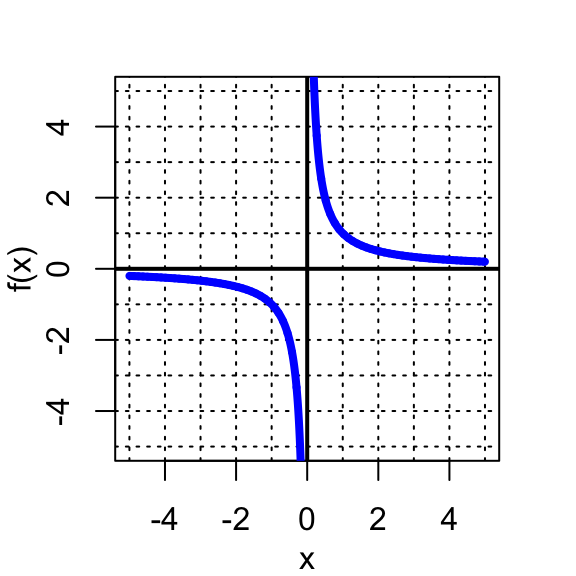

##ANSWER1##

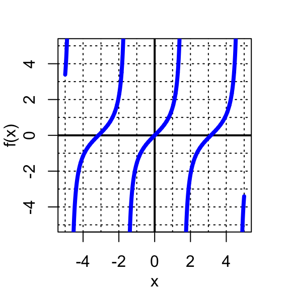

##ANSWER2##

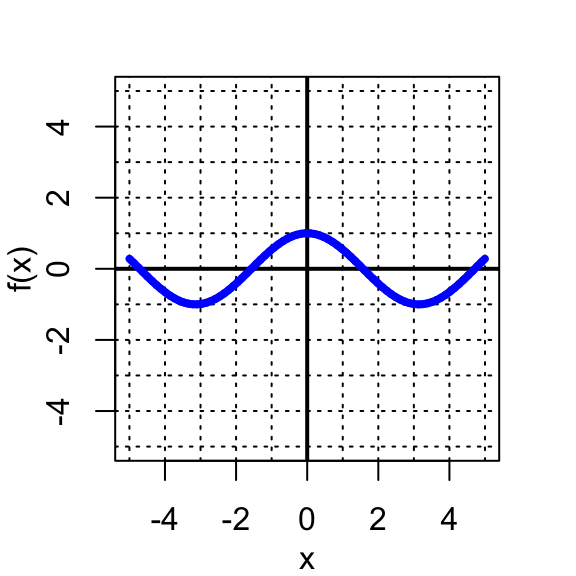

##ANSWER3##

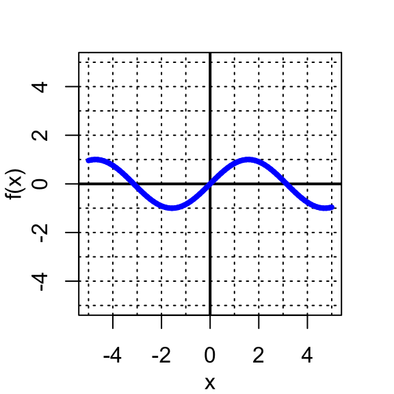

##ANSWER4##

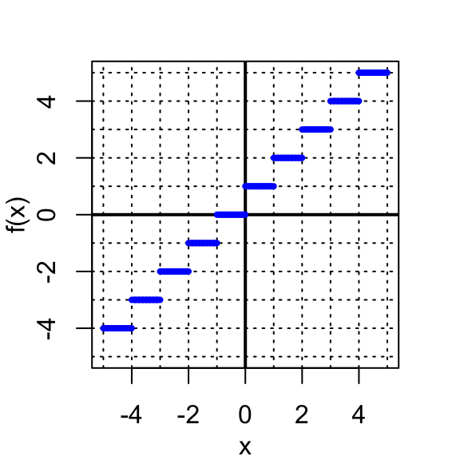

##ANSWER5##

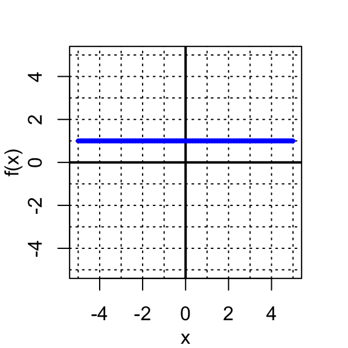

##ANSWER6##

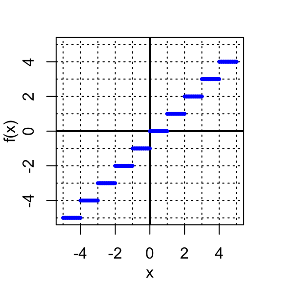

##ANSWER7##

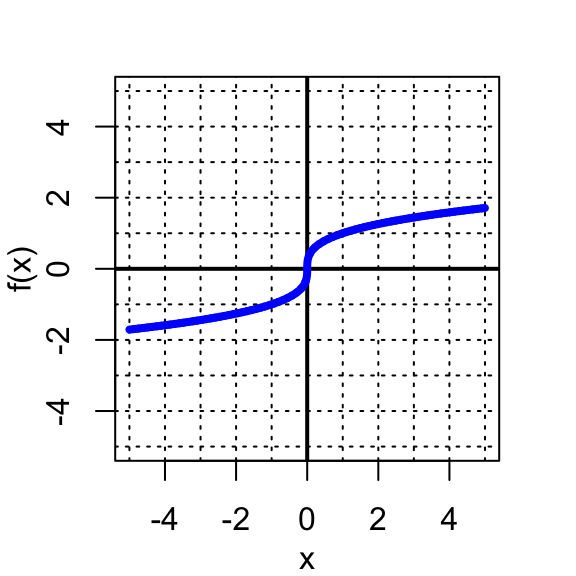

##ANSWER8##

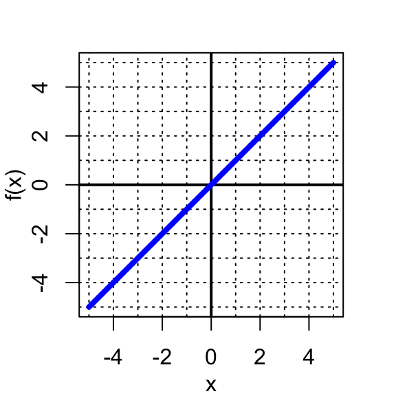

##ANSWER9##

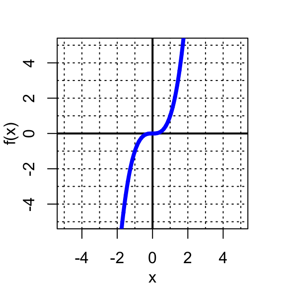

##ANSWER10##

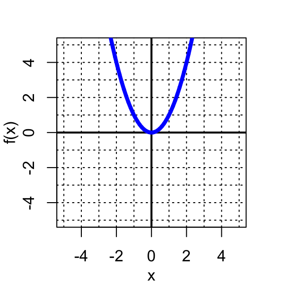

##ANSWER11##

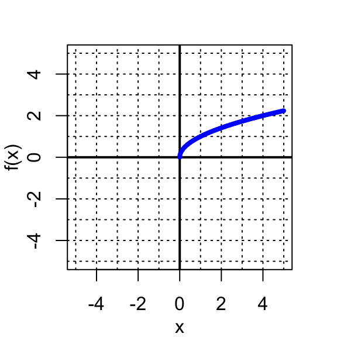

##ANSWER12##

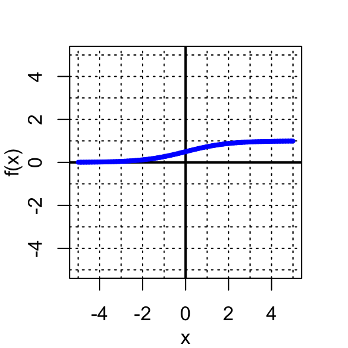

##ANSWER13##

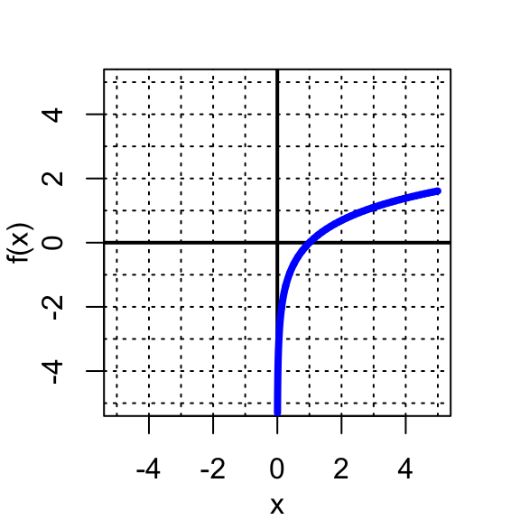

##ANSWER14##

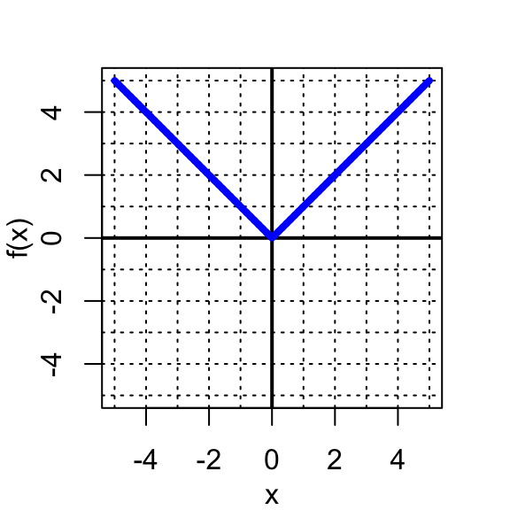

##ANSWER15##

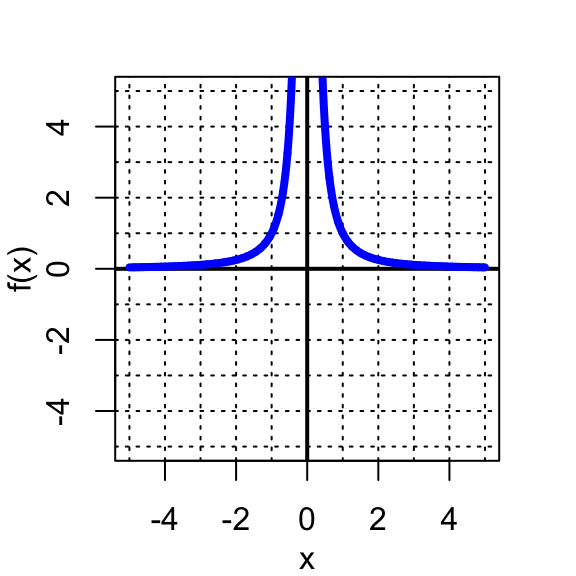

##ANSWER16##

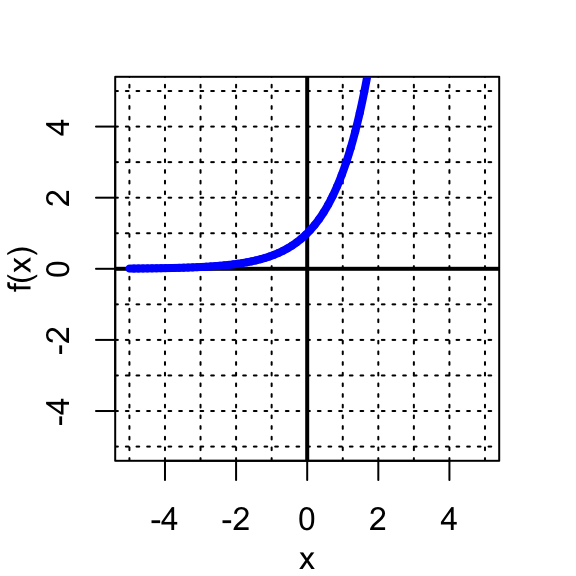

##ANSWER17##

## Answerlist

- constant
- linear
- absolute
- quadratic
- cubic
- reciprocal
- square root
- cube root
- sine
- cosine
- tangent
- ceiling
- floor
- exponential
- logarithmic
- logistic
- squared reciprocal
- constant
- linear
- absolute
- quadratic
- cubic
- reciprocal
- square root
- cube root
- sine
- cosine
- tangent
- ceiling
- floor
- exponential
- logarithmic
- logistic
- squared reciprocal
- constant
- linear
- absolute
- quadratic
- cubic
- reciprocal
- square root
- cube root
- sine
- cosine
- tangent
- ceiling
- floor
- exponential
- logarithmic
- logistic
- squared reciprocal
- constant
- linear
- absolute
- quadratic
- cubic
- reciprocal
- square root
- cube root
- sine
- cosine
- tangent
- ceiling
- floor
- exponential
- logarithmic
- logistic
- squared reciprocal
- constant
- linear
- absolute
- quadratic
- cubic
- reciprocal
- square root
- cube root
- sine
- cosine
- tangent
- ceiling
- floor
- exponential
- logarithmic
- logistic
- squared reciprocal
- constant
- linear
- absolute
- quadratic
- cubic
- reciprocal
- square root
- cube root
- sine
- cosine
- tangent
- ceiling
- floor
- exponential
- logarithmic
- logistic
- squared reciprocal
- constant
- linear
- absolute
- quadratic
- cubic
- reciprocal
- square root
- cube root
- sine
- cosine
- tangent
- ceiling
- floor
- exponential
- logarithmic
- logistic
- squared reciprocal
- constant
- linear
- absolute
- quadratic
- cubic
- reciprocal
- square root
- cube root
- sine
- cosine
- tangent
- ceiling
- floor
- exponential
- logarithmic
- logistic
- squared reciprocal
- constant
- linear
- absolute
- quadratic
- cubic
- reciprocal
- square root
- cube root
- sine
- cosine
- tangent
- ceiling
- floor
- exponential
- logarithmic
- logistic
- squared reciprocal
- constant
- linear
- absolute
- quadratic
- cubic
- reciprocal
- square root
- cube root
- sine
- cosine
- tangent
- ceiling
- floor
- exponential
- logarithmic
- logistic
- squared reciprocal
- constant
- linear
- absolute
- quadratic
- cubic
- reciprocal
- square root
- cube root
- sine
- cosine
- tangent
- ceiling
- floor
- exponential
- logarithmic
- logistic
- squared reciprocal
- constant
- linear
- absolute
- quadratic
- cubic
- reciprocal
- square root
- cube root
- sine
- cosine
- tangent
- ceiling
- floor
- exponential
- logarithmic
- logistic
- squared reciprocal
- constant
- linear
- absolute
- quadratic
- cubic
- reciprocal
- square root
- cube root
- sine
- cosine
- tangent
- ceiling
- floor
- exponential
- logarithmic
- logistic
- squared reciprocal
- constant
- linear
- absolute
- quadratic
- cubic
- reciprocal
- square root
- cube root
- sine
- cosine
- tangent
- ceiling
- floor
- exponential
- logarithmic
- logistic
- squared reciprocal
- constant
- linear
- absolute
- quadratic
- cubic
- reciprocal
- square root
- cube root
- sine
- cosine
- tangent
- ceiling
- floor
- exponential
- logarithmic
- logistic
- squared reciprocal
- constant
- linear
- absolute
- quadratic
- cubic
- reciprocal
- square root
- cube root
- sine
- cosine
- tangent
- ceiling
- floor
- exponential
- logarithmic
- logistic
- squared reciprocal
- constant
- linear
- absolute
- quadratic
- cubic
- reciprocal
- square root
- cube root
- sine
- cosine
- tangent
- ceiling
- floor
- exponential
- logarithmic
- logistic
- squared reciprocal

# Solution

You could try graphing the options or referencing a parent-function chart.

In Desmos, you can use `floor(x)` and `ceil(x)` for the floor and ceiling functions.

# Meta-information

extype: cloze exclozetype: schoice|schoice|schoice|schoice|schoice|schoice|schoice|schoice|schoice|schoice|schoice|schoice|schoice|schoice|schoice|schoice|schoice exsolution: 00000100000000000|00000000001000000|00000000010000000|00000000100000000|00000000000100000|10000000000000000|00000000000010000|00000001000000000|01000000000000000|00001000000000000|00010000000000000|00000010000000000|00000000000000010|00000000000000100|00100000000000000|00000000000000001|00000000000001000 exname: match_parent_functions exshuffle: false